# Análisis de la Temperatura en Málaga (1960-2023)

### 3. Estima el modelo que has propuesto en el apartado anterior y presenta sus resultados (las estimaciones de las varianzas y los componentes de la serie en el ultimo mes). Preferiblemente, usa la librerıa KFAS.

```r
# Extraer los componentes
tendencia_stl <- tail(descomp_stl$time.series[, "trend"], 1)
estacionalidad_stl <- tail(descomp_stl$time.series[, "seasonal"], 1)
residuo_stl <- tail(descomp_stl$time.series[, "remainder"], 1)


# Mostrar los componentes del último mes
tendencia_stl
```

```
##           Dec
## 2023 231.8388
```

```r
estacionalidad_stl
```

```
##            Dec
## 2023 -58.33783
```

```r
residuo_stl
```

```
##           Dec
## 2023 2.499049
```

### Estima los componentes de la serie con el modelo que has elegido finalmente usando el m´etodo con menor error cuadr´atico medio. Haz el gr´afico de los componentes con sus intervalos de confianza del 90 %.

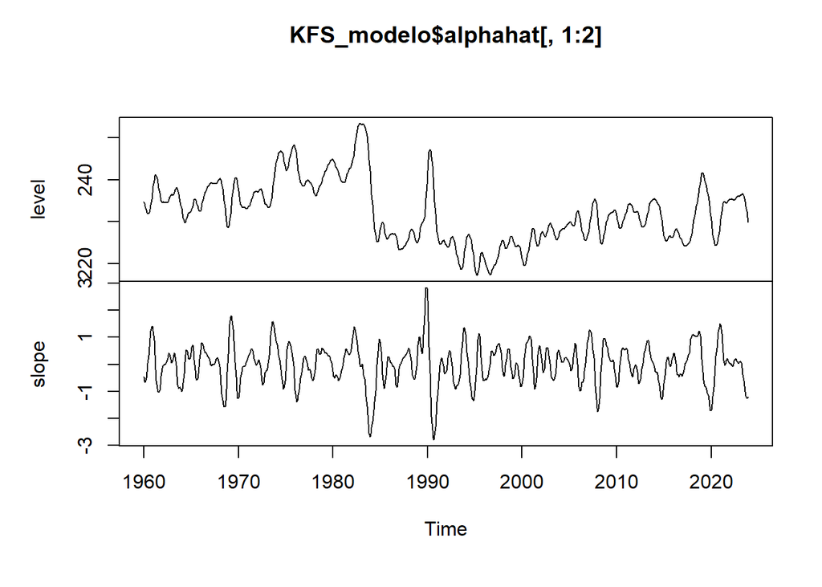

```r
# Cargar las librerías necesarias
library(KFAS)

# Suavizados

plot(KFS_modelo$alphahat[, 1:2])
```

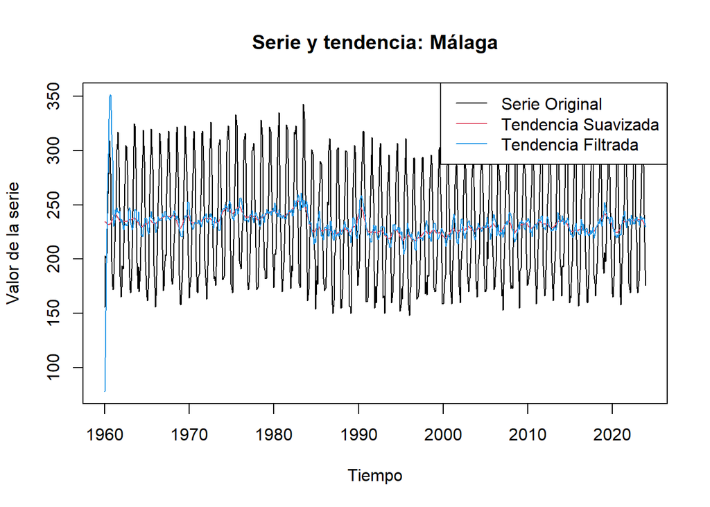

```r
# Graficar la serie temporal, la tendencia suavizada y la filtrada (sin logaritmo)
ts.plot(ts_malaga,
        KFS_modelo$alphahat[,1],
        KFS_modelo$att[,1],
        lty = 1:1,
        col = c(1, 2, 4),
        main = "Serie y tendencia: Málaga",
        ylab = "Valor de la serie",
        xlab = "Tiempo")

# Agregar leyenda
legend("topright",
       legend = c("Serie Original", "Tendencia Suavizada", "Tendencia Filtrada"),
       col = c(1, 2, 4),
       lty = 1:1)
```

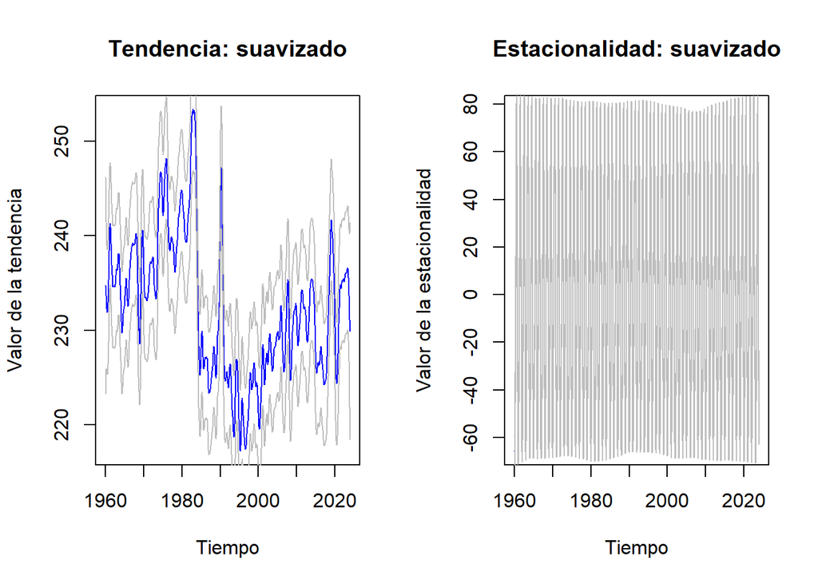

```r
# Extraer señales de nivel (tendencia)
levelbsm_malaga <- signal(KFS_modelo, states = c("level"))

# Extraer varianza de nivel
Vlevel_bsm_malaga <- ts(as.matrix(levelbsm_malaga$variance),
                        freq = frequency(ts_malaga),
                        start = c(start(ts_malaga)[1], start(ts_malaga)[2]))

# Señales de nivel
levelbsm_malaga <- levelbsm_malaga$signal

# Extraer señales de estacionalidad
seasbsm_malaga <- signal(KFS_modelo, states = c("seasonal"))

# Extraer varianza de estacionalidad
Vseas_bsm_malaga <- ts(as.matrix(seasbsm_malaga$variance),
                       freq = frequency(ts_malaga),
                       start = c(start(ts_malaga)[1], start(ts_malaga)[2]))

# Señales de estacionalidad
seasbsm_malaga <- seasbsm_malaga$signal


# Graficar las señales de nivel con intervalos de confianza
par(mfrow = c(1, 2))  # Organizar los gráficos en 2 columnas

# Graficar tendencia: suavizado
ts.plot(levelbsm_malaga,
        main = "Tendencia: suavizado",
        col = "blue",
        ylab = "Valor de la tendencia",
        xlab = "Tiempo")
lines(levelbsm_malaga - 1.96 * sqrt(Vlevel_bsm_malaga), col = "grey", lty = 1)
lines(levelbsm_malaga + 1.96 * sqrt(Vlevel_bsm_malaga), col = "grey", lty = 1)

# Graficar estacionalidad: suavizado
ts.plot(seasbsm_malaga,
        main = "Estacionalidad: suavizado",
        col = "blue",
        ylab = "Valor de la estacionalidad",
        xlab = "Tiempo")
lines(seasbsm_malaga - 1.96 * sqrt(Vseas_bsm_malaga), col = "grey", lty = 1)
lines(seasbsm_malaga + 1.96 * sqrt(Vseas_bsm_malaga), col = "grey", lty = 1)
```

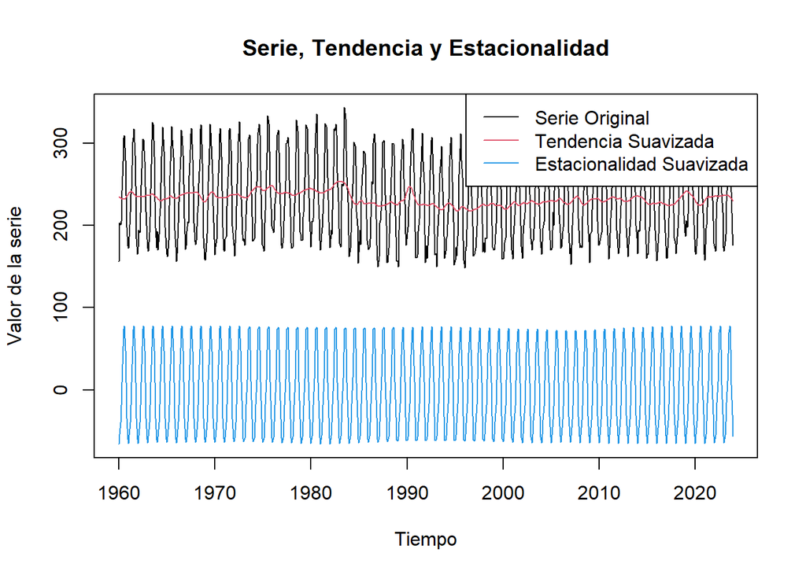

```r
par(mfrow = c(1, 1))  # Restablecer a una sola gráfica

# Graficar serie original junto con las componentes de tendencia y estacionalidad
ts.plot(ts_malaga,
        levelbsm_malaga,
        seasbsm_malaga,
        lty = 1:1,
        col = c(1, 2, 4),
        main = "Serie, Tendencia y Estacionalidad",
        ylab = "Valor de la serie",
        xlab = "Tiempo")

# Agregar leyenda
legend("topright",
       legend = c("Serie Original", "Tendencia Suavizada", "Estacionalidad Suavizada"),
       col = c(1, 2, 4),
       lty = 1:1)
```

El modelo con variables ficticias incluye una especificación estacional explícita mediante variables dummy, lo que le permite ajustar directamente las fluctuaciones de la serie debido a los efectos estacionales. Dado que la serie de temperaturas mensuales tiene un componente estacional fuerte, este modelo es capaz de capturar esos efectos de manera más precisa, a diferencia de los otros modelos (nivel local y tendencia lineal local), que no modelan de manera tan eficiente la estacionalidad.

El modelo con variables ficticias también tiene la capacidad de ajustarse a tendencias no lineales, algo que el modelo de nivel local no puede hacer.

Los residuos del modelo con variables ficticias mostraron una distribución más cercana a la normalidad en comparación con los residuos de los modelos de nivel local y tendencia lineal local Además, no mostraron signos tan evidentes de autocorrelación o heterocedasticidad, lo que sugiere que este modelo es el más adecuado para los datos,desde el punto de vista de los residuos.

```r
# Predicción para los próximos 12 meses con el modelo modelo_estructural_dummy
# Realizar las predicciones para los próximos 12 meses
pred_malaga <- predict(ajuste_modelo$model, n.ahead = 12, interval = "prediction", level = 0.9)



# Predicción de la tendencia para los próximos 12 meses
pred_tendencia <- predict(ajuste_modelo$model, n.ahead = 12, interval = "prediction", level = 0.9, state = "level")
str(pred_tendencia)
```

```
##  Time-Series [1:12, 1:3] from 2024 to 2025: 229 227 226 225 224 ...
##  - attr(*, "dimnames")=List of 2
##   ..$ : NULL
##   ..$ : chr [1:3] "fit" "lwr" "upr"
```

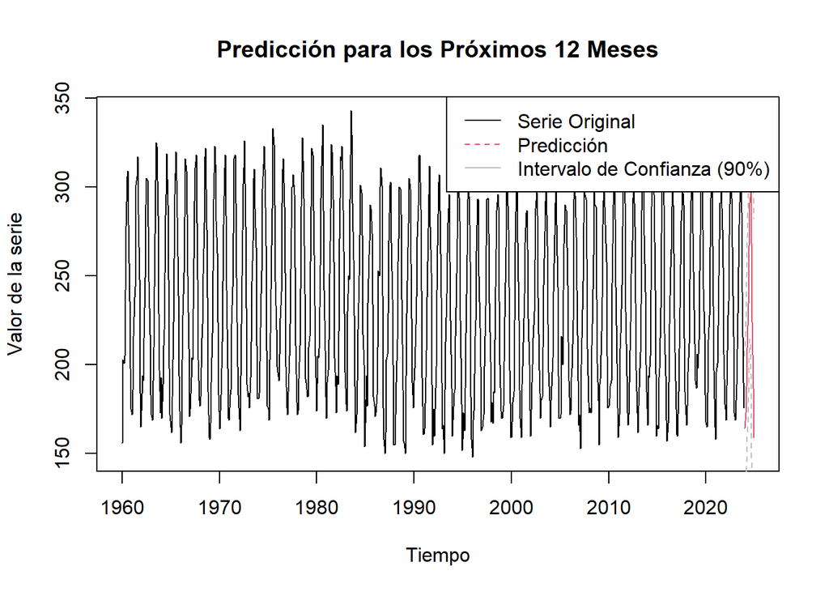

```r
# Predicción de la estacionalidad para los próximos 12 meses
pred_estacionalidad <- predict(ajuste_modelo$model, n.ahead = 12, interval = "prediction", level = 0.9, state = "seasonal")

# Extraer la predicción central, límite inferior y límite superior
pred_values <- pred_malaga[, "fit"]  # Predicción central
lwr_values <- pred_malaga[, "lwr"]   # Límite inferior
upr_values <- pred_malaga[, "upr"]   # Límite superior


# Extraer la predicción de la tendencia (ajuste)
tendencia_fit <- pred_tendencia[, "fit"]

# Extraer los límites inferior y superior
tendencia_lwr <- pred_tendencia[, "lwr"]
tendencia_upr <- pred_tendencia[, "upr"]

# Graficar la serie original junto con la predicción de los próximos 12 meses
ts.plot(ts_malaga,
        pred_values,
        lty = 1:1,
        col = c(1, 2),
        main = "Predicción para los Próximos 12 Meses",
        ylab = "Valor de la serie",
        xlab = "Tiempo")

# Agregar los intervalos de predicción (de 90%)
lines(pred_values + 1.96 * (upr_values - pred_values), col = "grey", lty = 2)
lines(pred_values - 1.96 * (pred_values - lwr_values), col = "grey", lty = 2)

# Leyenda
legend("topright",
       legend = c("Serie Original", "Predicción", "Intervalo de Confianza (90%)"),
       col = c(1, 2, "grey"),
       lty = 1:2)
```

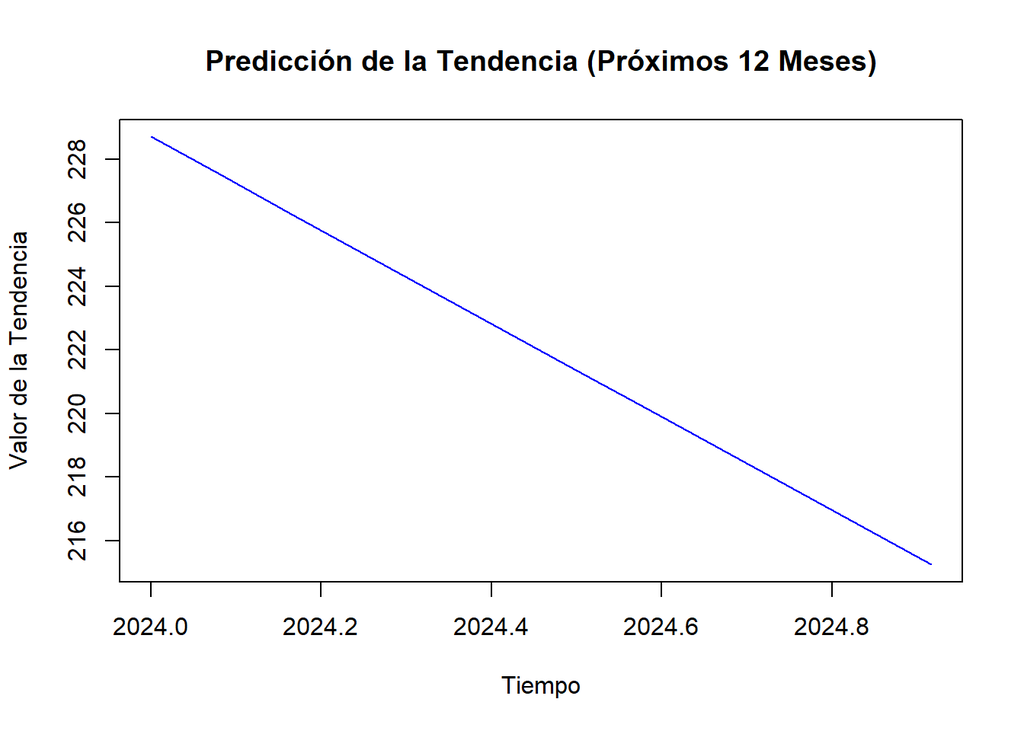

```r
# Graficar la predicción de la tendencia (ajuste)
ts.plot(tendencia_fit,
        main = "Predicción de la Tendencia (Próximos 12 Meses)",
        col = "blue",
        ylab = "Valor de la Tendencia",
        xlab = "Tiempo")

# Agregar los intervalos de confianza (límites inferior y superior)
lines(tendencia_lwr, col = "grey", lty = 2)
lines(tendencia_upr, col = "grey", lty = 2)
```

```r
# Extraer las predicciones de cada componente de la serie
pred_original <- pred_malaga[, 1]  # Acceder a la primera columna, que contiene las predicciones originales
pred_tendencia <- pred_tendencia  # Ya es un vector, así que simplemente lo asignamos
pred_estacionalidad <- pred_estacionalidad  # Lo mismo aquí, es un vector


# Crear el data frame con las predicciones para los próximos 12 meses
pred_df <- data.frame(
  Mes = seq(from = 2024, by = 1/12, length.out = 12),  # Generar los 12 meses de predicción
  Predicción_Original = pred_original,
  Predicción_Tendencia = pred_tendencia,
  Predicción_Estacionalidad = pred_estacionalidad
)

# Mostrar el data frame
print(pred_df)
```

```
##         Mes Predicción_Original Predicción_Tendencia.fit
## 1  2024.000            164.3041                 228.7053
## 2  2024.083            173.1322                 227.4819
## 3  2024.167            187.9752                 226.2585
## 4  2024.250            209.6509                 225.0352
## 5  2024.333            234.3364                 223.8118
## 6  2024.417            267.2259                 222.5884
## 7  2024.500            291.1474                 221.3651
## 8  2024.583            297.6918                 220.1417
## 9  2024.667            268.3491                 218.9183
## 10 2024.750            223.9738                 217.6950
## 11 2024.833            186.8533                 216.4716
## 12 2024.917            159.0810                 215.2482
##    Predicción_Tendencia.lwr Predicción_Tendencia.upr
## 1                  209.1877                 248.2228
```

[output cut: 37 more lines]

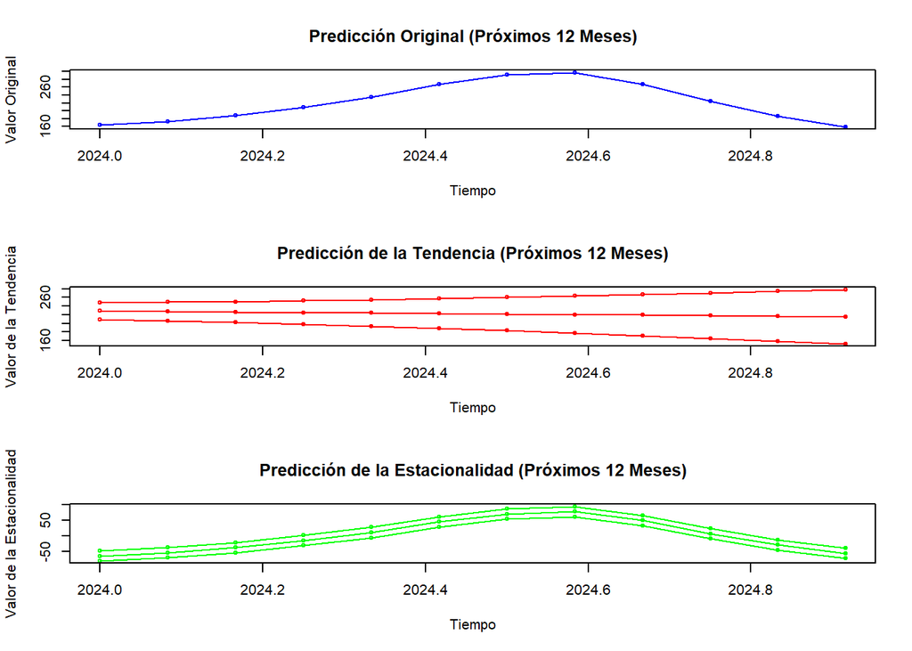

```r
# Crear un gráfico con la serie original, tendencia y estacionalidad
par(mfrow = c(3, 1))  # Dividir el gráfico en 3 filas para mostrar las 3 series

# Graficar la serie original
ts.plot(pred_original, main = "Predicción Original (Próximos 12 Meses)",
        col = "blue", ylab = "Valor Original", xlab = "Tiempo", type = "o")

# Graficar la tendencia
ts.plot(pred_tendencia, main = "Predicción de la Tendencia (Próximos 12 Meses)",
        col = "red", ylab = "Valor de la Tendencia", xlab = "Tiempo", type = "o")

# Graficar la estacionalidad
ts.plot(pred_estacionalidad, main = "Predicción de la Estacionalidad (Próximos 12 Meses)",
        col = "green", ylab = "Valor de la Estacionalidad", xlab = "Tiempo", type = "o")
```

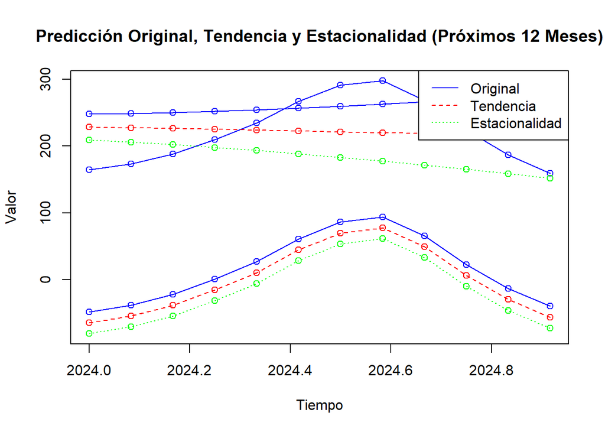

```r
# Restaurar configuración de gráficos
par(mfrow = c(1, 1))


# Graficar las tres series en un solo gráfico
ts.plot(pred_original, pred_tendencia, pred_estacionalidad,
        main = "Predicción Original, Tendencia y Estacionalidad (Próximos 12 Meses)",
        col = c("blue", "red", "green"),
        ylab = "Valor", xlab = "Tiempo", type = "o", lty = 1:3)

# Añadir una leyenda para identificar cada serie
legend("topright", legend = c("Original", "Tendencia", "Estacionalidad"),
       col = c("blue", "red", "green"), lty = 1:3)
```